# Caso_grupal_Detección_de_anomalías_y_técnicas_de_agrupamiento_25032025

## 1. Importación de Librerías

```python
# Librerías de manejo y análisis de datos
import pandas as pd
import numpy as np

# Librerías de visualización
import matplotlib.pyplot as plt
import seaborn as sb
from mpl_toolkits.mplot3d import Axes3D

# Librerías de preprocesamiento
from sklearn.preprocessing import StandardScaler

# Librerías de detección de anomalías
from sklearn.neighbors import LocalOutlierFactor
from sklearn.svm import OneClassSVM
from sklearn.ensemble import IsolationForest

# Librerías de clustering
from sklearn.cluster import KMeans
```

## 2. Carga y Preprocesamiento del Dataset

```python
from google.colab import drive
drive.mount('/content/drive')
```

```python
# Ruta al directorio raíz en Google Drive
dataset_path = '/content/drive/My Drive'

# Cargamos el dataset en un DataFrame y mostramos las primeras filas
df = pd.read_csv(dataset_path + '/resources/CTG.csv')
df.head()
```

|  | FileName | Date | SegFile | b | e | LBE | LB | AC | FM | UC | ... | C | D | E | AD | DE | LD | FS | SUSP | CLASS | NSP |
| --- | --- | --- | --- | --- | --- | --- | --- | --- | --- | --- | --- | --- | --- | --- | --- | --- | --- | --- | --- | --- | --- |
| 0 | Variab10.txt | 12/1/1996 | CTG0001.txt | 240.0 | 357.0 | 120.0 | 120.0 | 0.0 | 0.0 | 0.0 | ... | 0.0 | 0.0 | 0.0 | 0.0 | 0.0 | 0.0 | 1.0 | 0.0 | 9.0 | 2.0 |
| 1 | Fmcs_1.txt | 5/3/1996 | CTG0002.txt | 5.0 | 632.0 | 132.0 | 132.0 | 4.0 | 0.0 | 4.0 | ... | 0.0 | 0.0 | 0.0 | 1.0 | 0.0 | 0.0 | 0.0 | 0.0 | 6.0 | 1.0 |
| 2 | Fmcs_1.txt | 5/3/1996 | CTG0003.txt | 177.0 | 779.0 | 133.0 | 133.0 | 2.0 | 0.0 | 5.0 | ... | 0.0 | 0.0 | 0.0 | 1.0 | 0.0 | 0.0 | 0.0 | 0.0 | 6.0 | 1.0 |
| 3 | Fmcs_1.txt | 5/3/1996 | CTG0004.txt | 411.0 | 1192.0 | 134.0 | 134.0 | 2.0 | 0.0 | 6.0 | ... | 0.0 | 0.0 | 0.0 | 1.0 | 0.0 | 0.0 | 0.0 | 0.0 | 6.0 | 1.0 |
| 4 | Fmcs_1.txt | 5/3/1996 | CTG0005.txt | 533.0 | 1147.0 | 132.0 | 132.0 | 4.0 | 0.0 | 5.0 | ... | 0.0 | 0.0 | 0.0 | 0.0 | 0.0 | 0.0 | 0.0 | 0.0 | 2.0 | 1.0 |

5 rows × 40 columns

```python
# Eliminamos columnas de metadatos administrativos que no aportan
# información diagnóstica relevante para el análisis
df = df.drop(["FileName", "Date", "SegFile", "b", "e"], axis=1)
df.head()
```

|  | LBE | LB | AC | FM | UC | ASTV | MSTV | ALTV | MLTV | DL | ... | C | D | E | AD | DE | LD | FS | SUSP | CLASS | NSP |
| --- | --- | --- | --- | --- | --- | --- | --- | --- | --- | --- | --- | --- | --- | --- | --- | --- | --- | --- | --- | --- | --- |
| 0 | 120.0 | 120.0 | 0.0 | 0.0 | 0.0 | 73.0 | 0.5 | 43.0 | 2.4 | 0.0 | ... | 0.0 | 0.0 | 0.0 | 0.0 | 0.0 | 0.0 | 1.0 | 0.0 | 9.0 | 2.0 |
| 1 | 132.0 | 132.0 | 4.0 | 0.0 | 4.0 | 17.0 | 2.1 | 0.0 | 10.4 | 2.0 | ... | 0.0 | 0.0 | 0.0 | 1.0 | 0.0 | 0.0 | 0.0 | 0.0 | 6.0 | 1.0 |
| 2 | 133.0 | 133.0 | 2.0 | 0.0 | 5.0 | 16.0 | 2.1 | 0.0 | 13.4 | 2.0 | ... | 0.0 | 0.0 | 0.0 | 1.0 | 0.0 | 0.0 | 0.0 | 0.0 | 6.0 | 1.0 |
| 3 | 134.0 | 134.0 | 2.0 | 0.0 | 6.0 | 16.0 | 2.4 | 0.0 | 23.0 | 2.0 | ... | 0.0 | 0.0 | 0.0 | 1.0 | 0.0 | 0.0 | 0.0 | 0.0 | 6.0 | 1.0 |
| 4 | 132.0 | 132.0 | 4.0 | 0.0 | 5.0 | 16.0 | 2.4 | 0.0 | 19.9 | 0.0 | ... | 0.0 | 0.0 | 0.0 | 0.0 | 0.0 | 0.0 | 0.0 | 0.0 | 2.0 | 1.0 |

5 rows × 35 columns

```python
# Verificamos las dimensiones del dataset: (número de filas, número de columnas)
df.shape
```

```
(2129, 35)
```

```python
# Contamos los valores nulos por columna para evaluar la calidad del dataset
df.isnull().sum()
```

|  | 0 |
| --- | --- |
| LBE | 3 |
| LB | 3 |
| AC | 3 |
| FM | 2 |
| UC | 2 |
| ASTV | 2 |
| MSTV | 2 |
| ALTV | 2 |
| MLTV | 2 |
| DL | 1 |
| DS | 1 |
| DP | 1 |
| DR | 1 |
| Width | 3 |
| Min | 3 |
| Max | 3 |
| Nmax | 3 |
| Nzeros | 3 |
| Mode | 3 |
| Mean | 3 |
| Median | 3 |
| Variance | 3 |
| Tendency | 3 |
| A | 3 |
| B | 3 |
| C | 3 |
| D | 3 |
| E | 3 |
| AD | 3 |
| DE | 3 |
| LD | 3 |
| FS | 3 |
| SUSP | 3 |
| CLASS | 3 |
| NSP | 3 |

**dtype:** int64

```python
# Eliminamos filas con valores nulos (estrategia de eliminación simple)
df = df.dropna()

# Confirmamos que no queden valores nulos en el dataset
df.isnull().sum()
```

|  | 0 |
| --- | --- |
| LBE | 0 |
| LB | 0 |
| AC | 0 |
| FM | 0 |
| UC | 0 |
| ASTV | 0 |
| MSTV | 0 |
| ALTV | 0 |
| MLTV | 0 |
| DL | 0 |
| DS | 0 |
| DP | 0 |
| DR | 0 |
| Width | 0 |
| Min | 0 |
| Max | 0 |
| Nmax | 0 |
| Nzeros | 0 |
| Mode | 0 |
| Mean | 0 |
| Median | 0 |
| Variance | 0 |
| Tendency | 0 |
| A | 0 |
| B | 0 |
| C | 0 |
| D | 0 |
| E | 0 |
| AD | 0 |
| DE | 0 |
| LD | 0 |
| FS | 0 |
| SUSP | 0 |
| CLASS | 0 |
| NSP | 0 |

**dtype:** int64

```python
# Inspeccionamos los tipos de datos de cada columna y el uso de memoria
df.info()
```

```
<class 'pandas.core.frame.DataFrame'>
Index: 2126 entries, 0 to 2125
Data columns (total 35 columns):
 #   Column    Non-Null Count  Dtype
---  ------    --------------  -----
 0   LBE       2126 non-null   float64
 1   LB        2126 non-null   float64
 2   AC        2126 non-null   float64
 3   FM        2126 non-null   float64
 4   UC        2126 non-null   float64
 5   ASTV      2126 non-null   float64
 6   MSTV      2126 non-null   float64
 7   ALTV      2126 non-null   float64
 8   MLTV      2126 non-null   float64
 9   DL        2126 non-null   float64
```

[output cut: 27 more lines]

## 3. Análisis Exploratorio de Datos (EDA)

### 3.1 Balance del Dataset

El dataset tiene 3 clases de estado fetal: **1 = Normal**, **2 = Sospechoso**, **3 = Patológico**. Un dataset desbalanceado puede sesgar el entrenamiento de modelos.

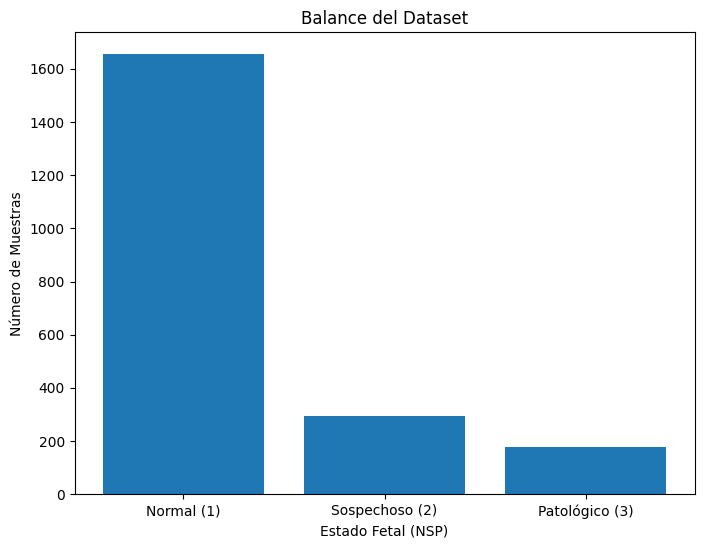

```python
# Contamos instancias por clase de estado fetal (NSP):
# 1 = Normal, 2 = Sospechoso, 3 = Patológico
# Un dataset desbalanceado puede afectar el rendimiento de los modelos
class_counts = df['NSP'].value_counts()

plt.figure(figsize=(8, 6))
plt.bar(class_counts.index, class_counts.values)
plt.xlabel('Estado Fetal (NSP)')
plt.ylabel('Número de Muestras')
plt.title('Balance del Dataset')
plt.xticks(class_counts.index, ['Normal (1)', 'Sospechoso (2)', 'Patológico (3)'])
plt.show()
```

### 3.2 Variables con Baja Variabilidad

Identificamos variables binarias (solo valores 0/1) y verificamos si alguna tiene tan poca variabilidad que no aporta información discriminatoria.

```python
# Identificamos variables que solo contienen valores 0 y 1
# para tratarlas como variables categóricas (indicadores binarios)
binary_variables = []
for column in df.columns:
    unique_values = df[column].unique()
    if all(value in [0, 1] for value in unique_values):
        binary_variables.append(column)

print("Variables binarias (tratadas como categóricas):", binary_variables)
```

```
Variables binarias (tratadas como categóricas): ['DS', 'DR', 'A', 'B', 'C', 'D', 'E', 'AD', 'DE', 'LD', 'FS', 'SUSP']
```

```python
# Creamos una copia del DataFrame para no alterar el original durante el preprocesamiento
df_copy = df.copy()

# Convertimos las variables binarias a tipo entero explícito
for column in binary_variables:
    df_copy[column] = df_copy[column].astype(int)
```

```python
# Verificamos los tipos de datos tras la conversión
df_copy.info()
```

```
<class 'pandas.core.frame.DataFrame'>
Index: 2126 entries, 0 to 2125
Data columns (total 35 columns):
 #   Column    Non-Null Count  Dtype
---  ------    --------------  -----
 0   LBE       2126 non-null   float64
 1   LB        2126 non-null   float64
 2   AC        2126 non-null   float64
 3   FM        2126 non-null   float64
 4   UC        2126 non-null   float64
 5   ASTV      2126 non-null   float64
 6   MSTV      2126 non-null   float64
 7   ALTV      2126 non-null   float64
 8   MLTV      2126 non-null   float64
 9   DL        2126 non-null   float64
```

[output cut: 27 more lines]

```python
# Contamos los valores igual a 0 por columna
# Una columna con casi todos ceros tiene baja variabilidad y poco poder discriminatorio
(df_copy == 0).sum(axis=0)
```

|  | 0 |
| --- | --- |
| LBE | 0 |
| LB | 0 |
| AC | 891 |
| FM | 1311 |
| UC | 332 |
| ASTV | 0 |
| MSTV | 0 |
| ALTV | 1240 |
| MLTV | 137 |
| DL | 1231 |
| DS | 2119 |
| DP | 1948 |
| DR | 2126 |
| Width | 0 |
| Min | 0 |
| Max | 0 |
| Nmax | 107 |
| Nzeros | 1624 |
| Mode | 0 |
| Mean | 0 |
| Median | 0 |
| Variance | 187 |
| Tendency | 1115 |
| A | 1742 |
| B | 1547 |
| C | 2073 |
| D | 2045 |
| E | 2054 |
| AD | 1794 |
| DE | 1874 |
| LD | 2019 |
| FS | 2057 |
| SUSP | 1929 |
| CLASS | 0 |
| NSP | 0 |

**dtype:** int64

```python
# 'DR' (deceleraciones repetitivas) tiene casi todos sus valores en 0,
# lo que indica baja variabilidad → la eliminamos para evitar ruido
df_copy = df_copy.drop('DR', axis=1)
df_copy.info()
```

```
<class 'pandas.core.frame.DataFrame'>
Index: 2126 entries, 0 to 2125
Data columns (total 34 columns):
 #   Column    Non-Null Count  Dtype
---  ------    --------------  -----
 0   LBE       2126 non-null   float64
 1   LB        2126 non-null   float64
 2   AC        2126 non-null   float64
 3   FM        2126 non-null   float64
 4   UC        2126 non-null   float64
 5   ASTV      2126 non-null   float64
 6   MSTV      2126 non-null   float64
 7   ALTV      2126 non-null   float64
 8   MLTV      2126 non-null   float64
 9   DL        2126 non-null   float64
```

[output cut: 26 more lines]

```python
# Convertimos a entero las variables ordinales:
# - Tendency: -1 (asimétrica izquierda), 0 (simétrica), 1 (asimétrica derecha)
# - NSP: 1 (Normal), 2 (Sospechoso), 3 (Patológico)
df_copy['Tendency'] = df_copy['Tendency'].astype('int64')
df_copy['NSP'] = df_copy['NSP'].astype('int64')
```

### 3.3 Separación de Variables Numéricas y Categóricas

Dividimos las variables en dos grupos para aplicar visualizaciones y análisis específicos a cada tipo.

```python
# Separamos variables según su tipo de dato:
# - Numéricas (float): mediciones continuas del CTG
# - Categóricas (int, object): etiquetas, clases y patrones morfológicos
lst_numvar = df_copy.select_dtypes(include=float).columns.to_list()
lst_catvar = df_copy.select_dtypes(include=int).columns.to_list() + df_copy.select_dtypes(include=object).columns.to_list()

print("Variables numéricas:", lst_numvar)
print("\nVariables categóricas:", lst_catvar)
```

```
Variables numéricas: ['LBE', 'LB', 'AC', 'FM', 'UC', 'ASTV', 'MSTV', 'ALTV', 'MLTV', 'DL', 'DP', 'Width', 'Min', 'Max', 'Nmax', 'Nzeros', 'Mode', 'Mean', 'Median', 'Variance', 'CLASS']

Variables categóricas: ['DS', 'Tendency', 'A', 'B', 'C', 'D', 'E', 'AD', 'DE', 'LD', 'FS', 'SUSP', 'NSP']
```

### 3.4 Distribución de Variables Categóricas

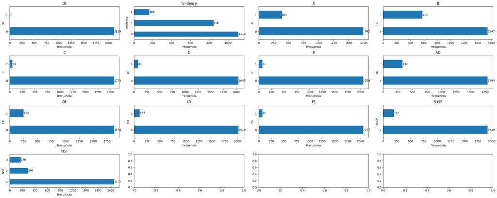

```python
# Graficamos la distribución de frecuencias de cada variable categórica
# usando barras horizontales para facilitar la lectura de etiquetas largas
fig, axes = plt.subplots(nrows=4, ncols=4, figsize=(25, 10))

plt.subplots_adjust(wspace=0.3, hspace=0.3)

for col, ax in zip(lst_catvar, axes.ravel()):
    df_copy[col].value_counts().plot.barh(ax=ax)
    ax.set_xlabel('Frecuencia')
    ax.set_title(col)
    ax.bar_label(ax.containers[0])  # Muestra el conteo exacto en cada barra

plt.tight_layout()
plt.show()
```

### 3.5 Distribución de Variables Numéricas

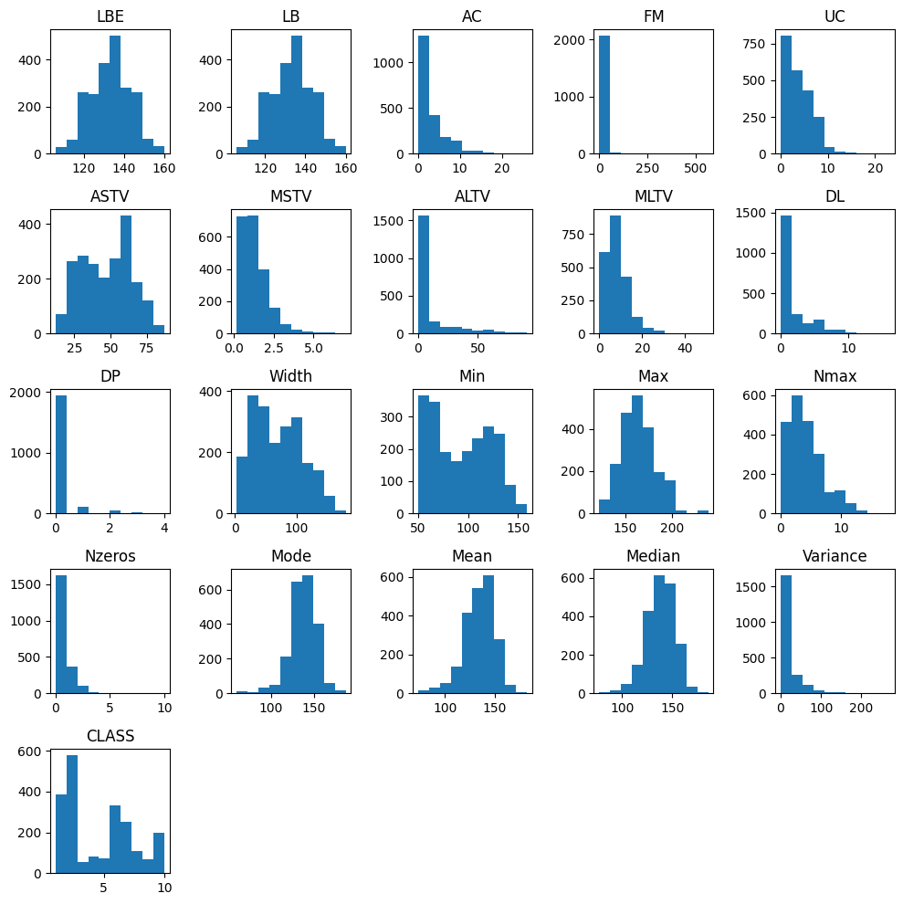

```python
# Histogramas para variables numéricas: permiten visualizar
# la distribución (normal, asimétrica, bimodal) de cada medición continua
df_copy[lst_numvar].hist(grid=False, figsize=(10, 10))
plt.tight_layout()
plt.show()
```

### 3.6 Relación de Variables Categóricas con el Estado Fetal (NSP)

Graficamos la distribución de cada variable categórica separada por clase NSP para identificar variables discriminantes.

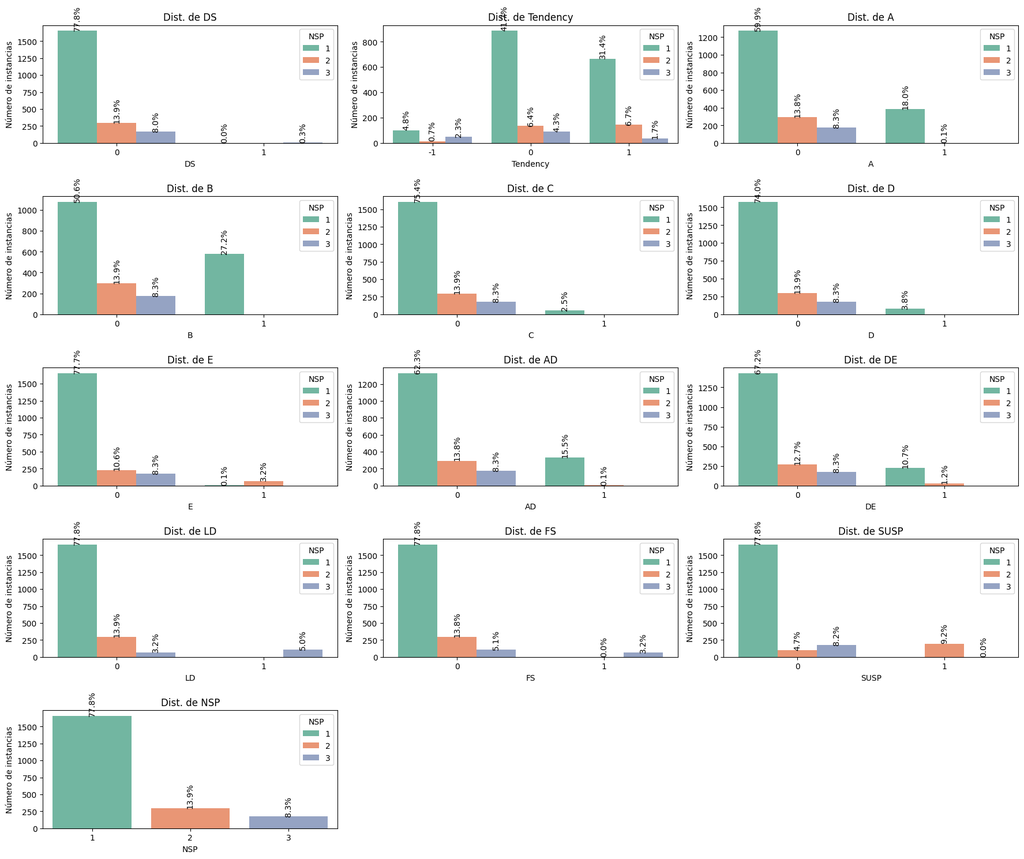

```python
cols = 3
rows = (len(lst_catvar) // cols) + 1

fig, axes = plt.subplots(rows, cols, figsize=(cols * 7, rows * 3))
axes = axes.flatten()

for idx, column in enumerate(lst_catvar):
    # Graficamos la distribución de cada variable categórica separada por clase NSP
    # Usamos df_copy (dataset preprocesado) para consistencia con el análisis
    ax = sb.countplot(x=column, hue='NSP', data=df_copy[lst_catvar], palette="Set2", ax=axes[idx])
    axes[idx].set_title(f"Dist. de {column}")
    axes[idx].set_xlabel(column)
    axes[idx].set_ylabel('Número de instancias')

    # Calculamos el porcentaje de cada barra respecto al total de instancias
    total = len(df_copy[lst_catvar])
    for p in ax.patches:
        height = p.get_height()
        if height > 0:
            percentage = f'{100 * height / total:.1f}%'
            x = p.get_x() + p.get_width() / 2
            y = p.get_y() + height
            ax.annotate(percentage, (x, y), ha='center', va='bottom', rotation=90)

# Ocultamos los subplots sobrantes que no tienen datos
for ax in axes[len(lst_catvar):]:
    fig.delaxes(ax)

plt.tight_layout(rect=[0, 0, 0.85, 1])
plt.show()
```

### 3.7 Matriz de Correlación (Variables Numéricas)

Coeficiente de Pearson: **+1** = correlación positiva perfecta, **-1** = negativa perfecta, **0** = sin correlación lineal. Útil para detectar redundancia entre variables.

[output not shown]

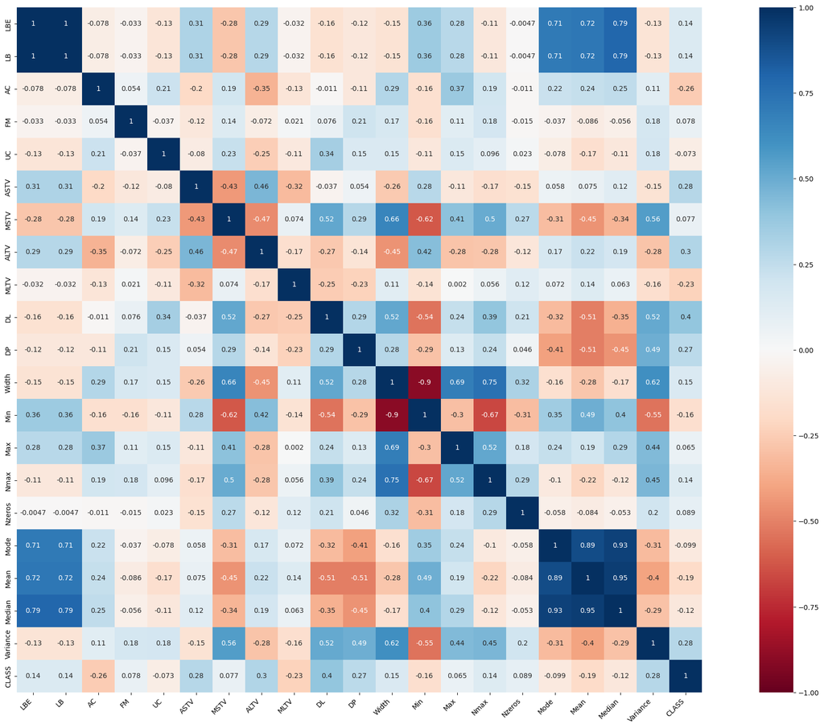

```python
# Calculamos la matriz de correlación de Pearson entre variables numéricas
# El mapa de calor facilita identificar pares de variables altamente correlacionadas
plt.figure(figsize=(30, 18))
corr = df_copy[lst_numvar].corr()
ax = sb.heatmap(corr, annot=True, cmap=plt.cm.RdBu, vmin=-1, vmax=1, center=0, square=True)
ax.set_xticklabels(ax.get_xticklabels(), rotation=45, horizontalalignment='right')
```

### 3.8 Boxplots y Estadísticas Descriptivas

Los diagramas de caja muestran la distribución de cada variable numérica. Los puntos fuera de los bigotes (Q1 − 1.5×IQR, Q3 + 1.5×IQR) son candidatos a outliers.

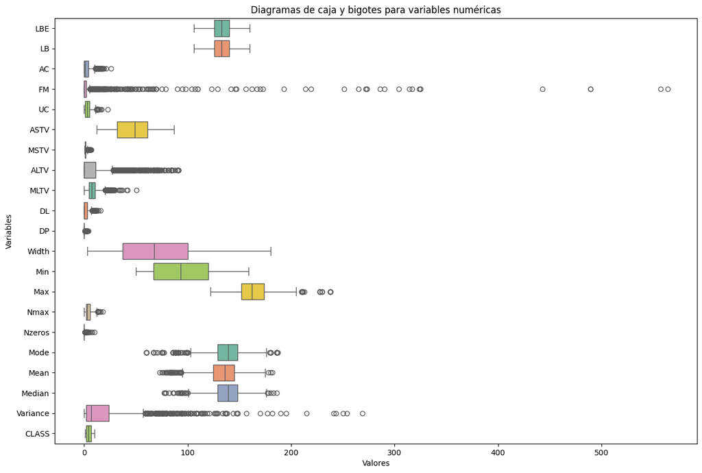

```python
# Diagramas de caja y bigotes para variables numéricas
# Los puntos fuera de los bigotes (1.5 × IQR) son candidatos a outliers
plt.figure(figsize=(15, 10))
sb.boxplot(data=df_copy[lst_numvar], orient="h", palette="Set2")
plt.title("Diagramas de caja y bigotes para variables numéricas")
plt.xlabel("Valores")
plt.ylabel("Variables")
plt.show()
```

```python
# Estadísticas descriptivas: media, desviación estándar, mínimo, máximo y percentiles
# Ayuda a entender la escala y variabilidad de cada variable
df_copy.describe()
```

|  | LBE | LB | AC | FM | UC | ASTV | MSTV | ALTV | MLTV | DL | ... | C | D | E | AD | DE | LD | FS | SUSP | CLASS | NSP |
| --- | --- | --- | --- | --- | --- | --- | --- | --- | --- | --- | --- | --- | --- | --- | --- | --- | --- | --- | --- | --- | --- |
| count | 2126.000000 | 2126.000000 | 2126.000000 | 2126.000000 | 2126.000000 | 2126.000000 | 2126.000000 | 2126.00000 | 2126.000000 | 2126.000000 | ... | 2126.000000 | 2126.000000 | 2126.000000 | 2126.000000 | 2126.000000 | 2126.000000 | 2126.000000 | 2126.000000 | 2126.000000 | 2126.000000 |
| mean | 133.303857 | 133.303857 | 2.722484 | 7.241298 | 3.659925 | 46.990122 | 1.332785 | 9.84666 | 8.187629 | 1.570085 | ... | 0.024929 | 0.038100 | 0.033866 | 0.156162 | 0.118532 | 0.050329 | 0.032455 | 0.092662 | 4.509878 | 1.304327 |
| std | 9.840844 | 9.840844 | 3.560850 | 37.125309 | 2.847094 | 17.192814 | 0.883241 | 18.39688 | 5.628247 | 2.499229 | ... | 0.155947 | 0.191482 | 0.180928 | 0.363094 | 0.323314 | 0.218675 | 0.177248 | 0.290027 | 3.026883 | 0.614377 |
| min | 106.000000 | 106.000000 | 0.000000 | 0.000000 | 0.000000 | 12.000000 | 0.200000 | 0.00000 | 0.000000 | 0.000000 | ... | 0.000000 | 0.000000 | 0.000000 | 0.000000 | 0.000000 | 0.000000 | 0.000000 | 0.000000 | 1.000000 | 1.000000 |
| 25% | 126.000000 | 126.000000 | 0.000000 | 0.000000 | 1.000000 | 32.000000 | 0.700000 | 0.00000 | 4.600000 | 0.000000 | ... | 0.000000 | 0.000000 | 0.000000 | 0.000000 | 0.000000 | 0.000000 | 0.000000 | 0.000000 | 2.000000 | 1.000000 |
| 50% | 133.000000 | 133.000000 | 1.000000 | 0.000000 | 3.000000 | 49.000000 | 1.200000 | 0.00000 | 7.400000 | 0.000000 | ... | 0.000000 | 0.000000 | 0.000000 | 0.000000 | 0.000000 | 0.000000 | 0.000000 | 0.000000 | 4.000000 | 1.000000 |
| 75% | 140.000000 | 140.000000 | 4.000000 | 2.000000 | 5.000000 | 61.000000 | 1.700000 | 11.00000 | 10.800000 | 3.000000 | ... | 0.000000 | 0.000000 | 0.000000 | 0.000000 | 0.000000 | 0.000000 | 0.000000 | 0.000000 | 7.000000 | 1.000000 |
| max | 160.000000 | 160.000000 | 26.000000 | 564.000000 | 23.000000 | 87.000000 | 7.000000 | 91.00000 | 50.700000 | 16.000000 | ... | 1.000000 | 1.000000 | 1.000000 | 1.000000 | 1.000000 | 1.000000 | 1.000000 | 1.000000 | 10.000000 | 3.000000 |

8 rows × 34 columns

## 4. Detección de Outliers Estadísticos

### 4.1 Método del Rango Intercuartílico (IQR)

Define límites estadísticos basados en cuartiles:

- **Límite inferior** = Q1 − 1.5 × IQR
- **Límite superior** = Q3 + 1.5 × IQR

Valores fuera de estos límites son considerados outliers potenciales.

```python
def iqr_outliers(df):
    """
    Detecta outliers con el método IQR (Rango Intercuartílico).
    Retorna un DataFrame con columnas booleanas: True = outlier.
    """
    outliers_df = pd.DataFrame()
    for column in df.select_dtypes(include=['number']).columns:
        Q1 = df[column].quantile(0.25)   # Primer cuartil (25%)
        Q3 = df[column].quantile(0.75)   # Tercer cuartil (75%)
        IQR = Q3 - Q1                    # Rango intercuartílico
        lower_bound = Q1 - 1.5 * IQR    # Límite inferior
        upper_bound = Q3 + 1.5 * IQR    # Límite superior

        # True donde el valor está fuera de los límites (outlier)
        outliers_df[column + '_outlier'] = (df[column] < lower_bound) | (df[column] > upper_bound)

        print(column)
        print(f"Límite inferior: {lower_bound:.4f}, Límite superior: {upper_bound:.4f}")
        print("Total de outliers: " + str(df[(df[column] < lower_bound) | (df[column] > upper_bound)].shape[0]))

    return outliers_df

outliers_iqr = iqr_outliers(df_copy[lst_numvar])
outliers_iqr
```

```
LBE
Límite inferior: 105.0000, Límite superior: 161.0000
Total de outliers: 0
LB
Límite inferior: 105.0000, Límite superior: 161.0000
Total de outliers: 0
AC
Límite inferior: -6.0000, Límite superior: 10.0000
Total de outliers: 83
FM
Límite inferior: -3.0000, Límite superior: 5.0000
Total de outliers: 310
UC
Límite inferior: -5.0000, Límite superior: 11.0000
Total de outliers: 22
ASTV
Límite inferior: -11.5000, Límite superior: 104.5000
Total de outliers: 0
MSTV
Límite inferior: -0.8000, Límite superior: 3.2000
Total de outliers: 70
ALTV
Límite inferior: -16.5000, Límite superior: 27.5000
Total de outliers: 309
MLTV
Límite inferior: -4.7000, Límite superior: 20.1000
Total de outliers: 71
DL
Límite inferior: -4.5000, Límite superior: 7.5000
Total de outliers: 81
DP
Límite inferior: 0.0000, Límite superior: 0.0000
Total de outliers: 178
Width
Límite inferior: -57.5000, Límite superior: 194.5000
Total de outliers: 0
Min
Límite inferior: -12.5000, Límite superior: 199.5000
Total de outliers: 0
Max
```

[output cut: 8 more lines]

```
Mode
Límite inferior: 100.5000, Límite superior: 176.5000
Total de outliers: 73
Mean
Límite inferior: 95.0000, Límite superior: 175.0000
Total de outliers: 45
Median
Límite inferior: 100.5000, Límite superior: 176.5000
Total de outliers: 28
Variance
Límite inferior: -31.0000, Límite superior: 57.0000
Total de outliers: 184
CLASS
Límite inferior: -5.5000, Límite superior: 14.5000
Total de outliers: 0
```

|  | LBE_outlier | LB_outlier | AC_outlier | FM_outlier | UC_outlier | ASTV_outlier | MSTV_outlier | ALTV_outlier | MLTV_outlier | DL_outlier | ... | Width_outlier | Min_outlier | Max_outlier | Nmax_outlier | Nzeros_outlier | Mode_outlier | Mean_outlier | Median_outlier | Variance_outlier | CLASS_outlier |
| --- | --- | --- | --- | --- | --- | --- | --- | --- | --- | --- | --- | --- | --- | --- | --- | --- | --- | --- | --- | --- | --- |
| 0 | False | False | False | False | False | False | False | True | False | False | ... | False | False | False | False | False | False | False | False | True | False |
| 1 | False | False | False | False | False | False | False | False | False | False | ... | False | False | False | False | True | False | False | False | False | False |
| 2 | False | False | False | False | False | False | False | False | False | False | ... | False | False | False | False | True | False | False | False | False | False |
| 3 | False | False | False | False | False | False | False | False | True | False | ... | False | False | False | False | False | False | False | False | False | False |
| 4 | False | False | False | False | False | False | False | False | False | False | ... | False | False | False | False | False | False | False | False | False | False |
| ... | ... | ... | ... | ... | ... | ... | ... | ... | ... | ... | ... | ... | ... | ... | ... | ... | ... | ... | ... | ... | ... |
| 2121 | False | False | False | False | False | False | False | False | False | False | ... | False | False | False | False | False | False | False | False | False | False |
| 2122 | False | False | False | False | False | False | False | False | False | False | ... | False | False | False | False | False | False | False | False | False | False |
| 2123 | False | False | False | False | False | False | False | False | False | False | ... | False | False | False | False | False | False | False | False | False | False |
| 2124 | False | False | False | False | False | False | False | False | False | False | ... | False | False | False | False | False | False | False | False | False | False |
| 2125 | False | False | False | False | False | False | False | True | False | False | ... | False | False | False | False | True | False | False | False | False | False |

2126 rows × 21 columns

```python
def count_below_zero_per_column(df):
    """
    Cuenta cuántos valores negativos hay por columna.
    Variables fisiológicas (frecuencias, conteos) no deberían ser negativas;
    su presencia puede indicar errores de medición.
    """
    below_zero_counts = {}
    for column in df.columns:
        below_zero_counts[column] = (df[column] < 0).sum()
    return below_zero_counts

below_zero_counts = count_below_zero_per_column(df_copy[lst_numvar])
below_zero_counts
```

```
{'LBE': np.int64(0),
 'LB': np.int64(0),
 'AC': np.int64(0),
 'FM': np.int64(0),
 'UC': np.int64(0),
 'ASTV': np.int64(0),
 'MSTV': np.int64(0),
 'ALTV': np.int64(0),
 'MLTV': np.int64(0),
 'DL': np.int64(0),
 'DP': np.int64(0),
 'Width': np.int64(0),
 'Min': np.int64(0),
 'Max': np.int64(0),
 'Nmax': np.int64(0),
 'Nzeros': np.int64(0),
 'Mode': np.int64(0),
 'Mean': np.int64(0),
 'Median': np.int64(0),
 'Variance': np.int64(0),
 'CLASS': np.int64(0)}
```

### 4.2 IQR con Ajuste de Límite Inferior

Variables fisiológicas (frecuencias cardíacas, conteos) no pueden ser negativas. Cuando el límite inferior del IQR resulta negativo, se ajusta a 0. Excepción: `Tendency`, que sí admite valores negativos (asimetría izquierda).

```python
def iqr_outliers_adjust_lower_bound(df):
    """
    Versión ajustada de IQR: si el límite inferior calculado es negativo
    y la variable no admite valores negativos (excepto 'Tendency'),
    se reemplaza por 0 para evitar falsos positivos.
    """
    outliers_df = pd.DataFrame()
    tendency = 'Tendency'

    for column in df.select_dtypes(include=['number']).columns:
        Q1 = df[column].quantile(0.25)
        Q3 = df[column].quantile(0.75)
        IQR = Q3 - Q1
        lower_bound = Q1 - 1.5 * IQR
        # Ajuste: las variables fisiológicas no pueden ser negativas
        lower_bound = 0 if lower_bound < 0 and column != tendency else lower_bound
        upper_bound = Q3 + 1.5 * IQR

        print("Columna: " + column)
        print(f"Límite inferior: {lower_bound:.4f}, Límite superior: {upper_bound:.4f}")
        print("Total de outliers: " + str(df[(df[column] < lower_bound) | (df[column] > upper_bound)].shape[0]))
        print(50 * '-')

    return outliers_df

outliers_iqr = iqr_outliers_adjust_lower_bound(df_copy[lst_numvar])
```

```
Columna: LBE
Límite inferior: 105.0000, Límite superior: 161.0000
Total de outliers: 0
--------------------------------------------------
Columna: LB
Límite inferior: 105.0000, Límite superior: 161.0000
Total de outliers: 0
--------------------------------------------------
Columna: AC
Límite inferior: 0.0000, Límite superior: 10.0000
Total de outliers: 83
--------------------------------------------------
Columna: FM
Límite inferior: 0.0000, Límite superior: 5.0000
Total de outliers: 310
--------------------------------------------------
Columna: UC
Límite inferior: 0.0000, Límite superior: 11.0000
Total de outliers: 22
--------------------------------------------------
Columna: ASTV
Límite inferior: 0.0000, Límite superior: 104.5000
Total de outliers: 0
--------------------------------------------------
Columna: MSTV
Límite inferior: 0.0000, Límite superior: 3.2000
Total de outliers: 70
--------------------------------------------------
Columna: ALTV
Límite inferior: 0.0000, Límite superior: 27.5000
Total de outliers: 309
--------------------------------------------------
Columna: MLTV
Límite inferior: 0.0000, Límite superior: 20.1000
Total de outliers: 71
--------------------------------------------------
Columna: DL
Límite inferior: 0.0000, Límite superior: 7.5000
Total de outliers: 81
--------------------------------------------------
```

[output cut: 29 more lines]

```
Límite inferior: 95.0000, Límite superior: 175.0000
Total de outliers: 45
--------------------------------------------------
Columna: Median
Límite inferior: 100.5000, Límite superior: 176.5000
Total de outliers: 28
--------------------------------------------------
Columna: Variance
Límite inferior: 0.0000, Límite superior: 57.0000
Total de outliers: 184
--------------------------------------------------
Columna: CLASS
Límite inferior: 0.0000, Límite superior: 14.5000
Total de outliers: 0
--------------------------------------------------
```

### 4.3 Regla de las 3 Desviaciones Estándar (3σ)

Bajo distribución normal, el **99.7%** de los datos cae dentro de ±3σ de la media. Valores más allá de ese rango son outliers estadísticos.

```python
def out_std(df, column):
    """
    Detecta outliers usando la regla de las 3 desviaciones estándar (3σ).
    Media ± 3σ cubre el 99.7% de los datos bajo una distribución normal.
    """
    tendency = 'Tendency'
    data_mean, data_std = df[column].mean(), df[column].std()
    cut_off = data_std * 3
    lower_bound = data_mean - cut_off
    # Ajuste: variables fisiológicas no pueden ser negativas (excepto Tendency)
    lower_bound = 0 if lower_bound < 0 and column != tendency else lower_bound
    upper_bound = data_mean + cut_off

    print(f'Límite inferior: {lower_bound:.2f} \t Límite superior: {upper_bound:.2f}')
    print("Total de outliers: " + str(df[(df[column] < lower_bound) | (df[column] > upper_bound)].shape[0]))


for col in list(df_copy[lst_numvar].columns):
    print(col)
    out_std(df_copy[lst_numvar], col)
    print(25 * '--')
```

```
LBE
Límite inferior: 103.78 	 Límite superior: 162.83
Total de outliers: 0
--------------------------------------------------
LB
Límite inferior: 103.78 	 Límite superior: 162.83
Total de outliers: 0
--------------------------------------------------
AC
Límite inferior: 0.00 	 Límite superior: 13.41
Total de outliers: 35
--------------------------------------------------
FM
Límite inferior: 0.00 	 Límite superior: 118.62
Total de outliers: 31
--------------------------------------------------
UC
Límite inferior: 0.00 	 Límite superior: 12.20
Total de outliers: 13
--------------------------------------------------
ASTV
Límite inferior: 0.00 	 Límite superior: 98.57
Total de outliers: 0
--------------------------------------------------
MSTV
Límite inferior: 0.00 	 Límite superior: 3.98
Total de outliers: 33
--------------------------------------------------
ALTV
Límite inferior: 0.00 	 Límite superior: 65.04
Total de outliers: 59
--------------------------------------------------
MLTV
Límite inferior: 0.00 	 Límite superior: 25.07
Total de outliers: 33
--------------------------------------------------
DL
Límite inferior: 0.00 	 Límite superior: 9.07
Total de outliers: 28
--------------------------------------------------
```

[output cut: 29 more lines]

```
Límite inferior: 87.83 	 Límite superior: 181.39
Total de outliers: 26
--------------------------------------------------
Median
Límite inferior: 94.69 	 Límite superior: 181.49
Total de outliers: 16
--------------------------------------------------
Variance
Límite inferior: 0.00 	 Límite superior: 105.74
Total de outliers: 44
--------------------------------------------------
CLASS
Límite inferior: 0.00 	 Límite superior: 13.59
Total de outliers: 0
--------------------------------------------------
```

## 5. Detección de Anomalías con Machine Learning

Los métodos estadísticos asumen distribuciones conocidas. Los algoritmos de ML detectan anomalías aprendiendo la estructura de los datos sin esa suposición.

### 5.1 Isolation Forest

Construye árboles de decisión aleatorios. Las anomalías son más fáciles de aislar (requieren menos particiones), por lo que obtienen **scores más bajos** (negativos).

[output not shown]

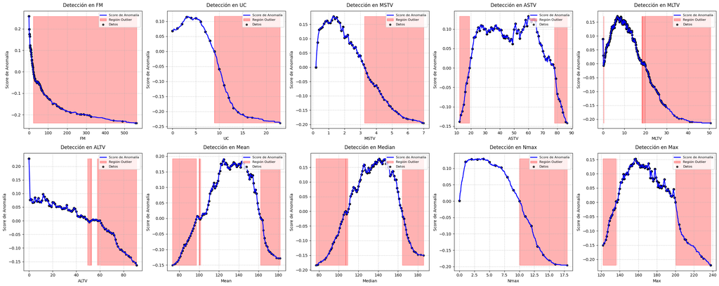

```python
# Variables seleccionadas para el análisis de anomalías con Isolation Forest
# (variables con mayor relevancia diagnóstica según la correlación)
correlated_vars = ['FM', 'UC', 'MSTV', 'ASTV', 'MLTV', 'ALTV', 'Mean', 'Median', 'Nmax', 'Max']
df_correlated = df_copy[correlated_vars]

fig, axs = plt.subplots(2, 5, figsize=(25, 10), facecolor='w', edgecolor='k')
axs = axs.ravel()
plt.subplots_adjust(wspace=0.5, hspace=0.5)

for i, column in enumerate(correlated_vars):
    # Entrenamos un Isolation Forest univariado por cada variable
    # contamination=0.05: asumimos que ~5% de los datos son anomalías
    isolation_forest = IsolationForest(contamination=0.05, random_state=42)
    isolation_forest.fit(df_correlated[[column]])

    # Generamos una secuencia de puntos para graficar la curva del score
    xx = np.linspace(df_correlated[column].min(), df_correlated[column].max(), 1000).reshape(-1, 1)
    anomaly_score = isolation_forest.decision_function(xx)  # Score: valores negativos = anomalía
    outlier = isolation_forest.predict(xx)                  # -1 = outlier, 1 = inlier

    # Score de anomalía para cada punto real del dataset
    data_scores = isolation_forest.decision_function(df_correlated[[column]])

    axs[i].plot(xx, anomaly_score, label='Score de Anomalía', color='blue', linewidth=2)
    axs[i].fill_between(xx.ravel(), np.min(anomaly_score), np.max(anomaly_score),
                        where=outlier == -1, color='red', alpha=0.3, label='Región Outlier')
    axs[i].scatter(df_correlated[column], data_scores, color='black', s=20, alpha=0.7, label='Datos')

    axs[i].set_title(f"Detección en {column}", fontsize=12, pad=10)
    axs[i].set_xlabel(column, fontsize=10)
    axs[i].set_ylabel("Score de Anomalía", fontsize=10)
    axs[i].grid(True, linestyle='--', alpha=0.6)
    axs[i].legend(loc='upper right', fontsize=8)

plt.tight_layout()
plt.show()
```

### 5.2 Local Outlier Factor (LOF)

Compara la **densidad local** de cada punto con la de sus vecinos. Un punto en una zona de baja densidad rodeado de puntos en alta densidad obtiene un score alto → anomalía. Requiere normalización previa para que ninguna variable domine por escala.

```python
# Seleccionamos FM (movimientos fetales) y UC (contracciones uterinas)
# para el análisis bivariado de anomalías
columnas = ['FM', 'UC']

# Normalizamos con StandardScaler: media=0, std=1
# Obligatorio para algoritmos basados en distancias como LOF,
# para que ninguna variable domine por tener mayor escala
scaler = StandardScaler()
data_scaled = scaler.fit_transform(df_copy[columnas])

print("Primeras 5 filas normalizadas:\n", data_scaled[:5])
```

```
Primeras 5 filas normalizadas:
 [[-0.19509607 -1.28579753]
 [-0.19509607  0.11947457]
 [-0.19509607  0.47079259]
 [-0.19509607  0.82211062]
 [-0.19509607  0.47079259]]
```

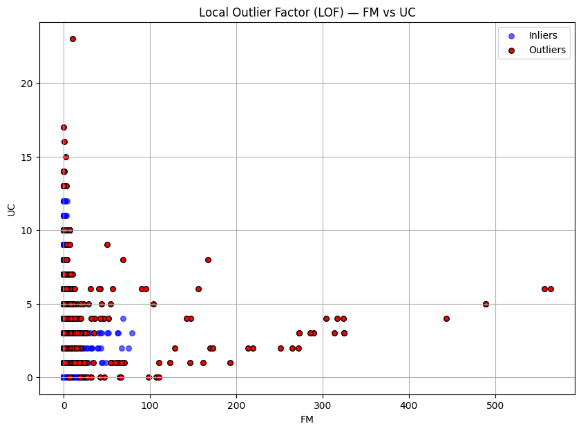

```python
# Referencia a los datos originales (sin escalar) para visualizar en escala real
df_2 = df_copy[columnas]
X_2 = df_2.to_numpy()

# LOF: n_neighbors=50 → número de vecinos para estimar la densidad local
# contamination='auto' → estima la proporción de outliers automáticamente
clf = LocalOutlierFactor(n_neighbors=50, contamination='auto')
y_pred = clf.fit_predict(data_scaled)  # Entrenamos sobre datos escalados

# Guardamos predicciones en el DataFrame: 1 = inlier, -1 = outlier
df_copy['Outlier'] = y_pred

plt.figure(figsize=(10, 7))

# Máscaras para separar inliers y outliers en el gráfico
in_mask = [l == 1 for l in y_pred]
out_mask = [l == -1 for l in y_pred]

plt.title("Local Outlier Factor (LOF) — FM vs UC")

# Graficamos en espacio original para mejor interpretabilidad clínica
plt.scatter(X_2[in_mask, 0], X_2[in_mask, 1],
            color='blue', label='Inliers', alpha=0.6, s=30)
plt.scatter(X_2[out_mask, 0], X_2[out_mask, 1],
            color='red', label='Outliers', edgecolors='k', s=30)

plt.xlabel(columnas[0])
plt.ylabel(columnas[1])
plt.legend()
plt.grid(True)
plt.show()
```

### 5.3 One-Class SVM

Aprende una **frontera de decisión** alrededor de los datos normales en un espacio de alta dimensión. Puntos fuera de esa frontera se clasifican como anomalías.

- `kernel='rbf'`: captura patrones no lineales
- `nu=0.05`: cota superior de la fracción de outliers esperada (~5%)

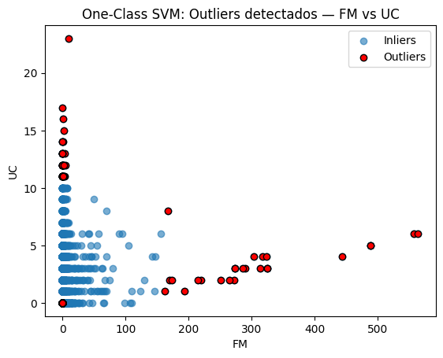

```python
# Entrenamos con datos escalados para consistencia con LOF
one_SVM = OneClassSVM(kernel='rbf', gamma=0.001, nu=0.05)
one_SVM.fit(data_scaled)            # Entrenamos con datos escalados
y_pred = one_SVM.predict(data_scaled)  # Predecimos sobre datos escalados

# Recuperamos los outliers en escala original para la visualización
outliers_values = df_2.iloc[np.where(y_pred == -1)]

plt.title("One-Class SVM: Outliers detectados — FM vs UC")
plt.scatter(df_2[columnas[0]], df_2[columnas[1]],
            alpha=0.6, label='Inliers')
plt.scatter(outliers_values[columnas[0]], outliers_values[columnas[1]],
            color='red', edgecolors='k', label='Outliers')
plt.axis('tight')
plt.xlabel(columnas[0])
plt.ylabel(columnas[1])
plt.legend()
plt.show()
```

## 6. Evaluación de los Métodos de Detección

Comparamos los outliers detectados por LOF con las etiquetas reales NSP. Esto permite validar si el método no supervisado identifica correctamente los casos patológicos sin haber visto las etiquetas durante el entrenamiento.

```
Distribución de outliers LOF por clase NSP:
Outlier_label  Inlier  Outlier
NSP_label
Normal           1208      447
Patológico        105       71
Sospechoso        246       49

Porcentaje de outliers por clase NSP:
Outlier_label  Inlier  Outlier
NSP_label
Normal           73.0     27.0
Patológico       59.7     40.3
Sospechoso       83.4     16.6
```

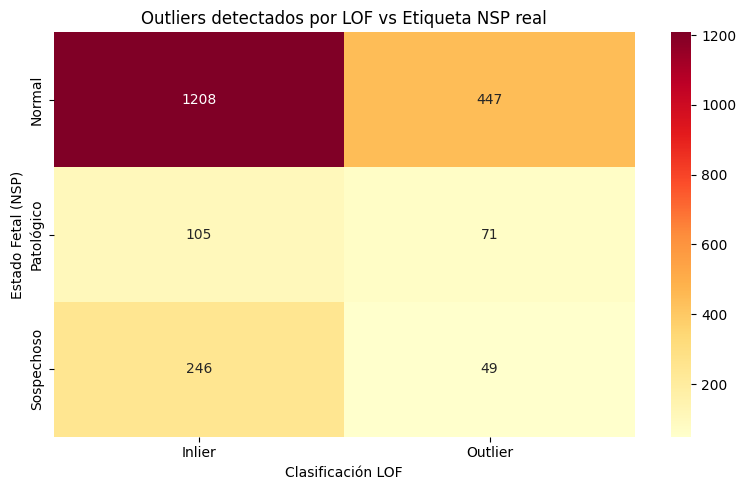

```python
# Comparamos outliers detectados por LOF vs etiquetas reales de estado fetal (NSP)
outlier_eval = df_copy[['NSP', 'Outlier']].copy()
outlier_eval['Outlier_label'] = outlier_eval['Outlier'].map({1: 'Inlier', -1: 'Outlier'})
outlier_eval['NSP_label'] = outlier_eval['NSP'].map({1: 'Normal', 2: 'Sospechoso', 3: 'Patológico'})

# Tabla cruzada: filas = clase NSP, columnas = clasificación LOF
ct = pd.crosstab(outlier_eval['NSP_label'], outlier_eval['Outlier_label'])
print("Distribución de outliers LOF por clase NSP:")
print(ct)
print()
print("Porcentaje de outliers por clase NSP:")
print((ct.div(ct.sum(axis=1), axis=0) * 100).round(1))

# Heatmap para visualizar la relación
plt.figure(figsize=(8, 5))
sb.heatmap(ct, annot=True, fmt='d', cmap='YlOrRd')
plt.title('Outliers detectados por LOF vs Etiqueta NSP real')
plt.ylabel('Estado Fetal (NSP)')
plt.xlabel('Clasificación LOF')
plt.tight_layout()
plt.show()
```

## 7. Agrupamiento (Clustering) con K-Means

K-Means particiona el dataset en **K grupos** minimizando la inercia (suma de distancias cuadradas al centroide más cercano). No requiere etiquetas: es aprendizaje **no supervisado**.

### 7.1 Método del Codo (Elbow Method)

Graficamos el score (inercia negativa) para K de 1 a 9. El punto donde la curva 'dobla' sugiere el número óptimo de clusters.

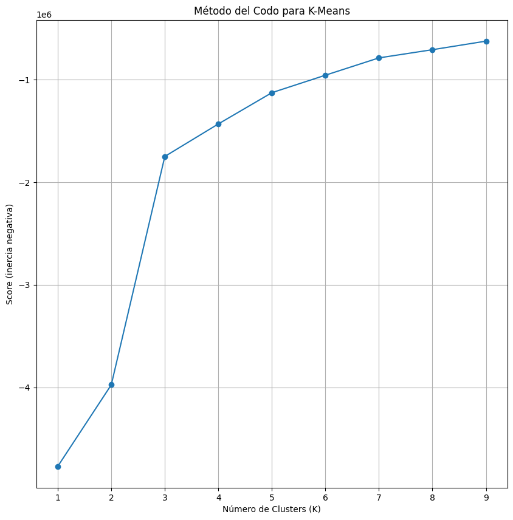

```python
# Usamos df_copy (dataset preprocesado) para consistencia con el análisis
df_3 = df_copy[['LB', 'AC', 'FM', 'UC', 'ASTV', 'MSTV', 'Mean', 'Median']]
X_3 = df_3.to_numpy()

# Probamos K desde 1 hasta 9 y calculamos el score de cada modelo
Nc = range(1, 10)
kmeans = [KMeans(n_clusters=i, random_state=42) for i in Nc]
score = [kmeans[i].fit(X_3).score(X_3) for i in range(len(kmeans))]

plt.rcParams['figure.figsize'] = (10, 10)
plt.plot(Nc, score, marker='o')
plt.xlabel('Número de Clusters (K)')
plt.ylabel('Score (inercia negativa)')
plt.title('Método del Codo para K-Means')
plt.grid(True)
plt.show()
```